# An Exploration of Lobbying in Chicago

Claire Herdeman

2/4/2019

# Background

The Chicago Board of Ethics requires that all lobbyists engaging with City officials register with the Board and file regular activity reports. The activity reports are filed electronically and include compensation paid to lobbyists by clients (the organizations and firms that hire lobbyists), lobbyist contributions to public and elected City officials, and lobbying activities (meetings with government departments or officials) conducted on behalf of clients.

The recent controversy surrounding unregistered lobbying by individuals contacting Mayor Rahm Emmanuel through his personal email account (see [here](https://www.chicagotribune.com/news/local/politics/ct-rahm-emanuel-emails-chicago-board-of-ethics-met-0420-20170419-story.html), [here](https://www.chicagotribune.com/news/local/politics/ct-chicago-lobbyist-registration-violations-met-0722-20170721-story.html), and [here](https://www.chicagotribune.com/news/local/politics/ct-rahm-emanuel-chicago-lobbying-violations-met-0720-20170719-story.html)), suggests that there is additional unregistered lobbying activity happening in Chicago. This analysis necessarily focuses only on registered activity reported to the City and made electronically available on the City of Chicago’s Open Data Portal.

# Lobbying Activity

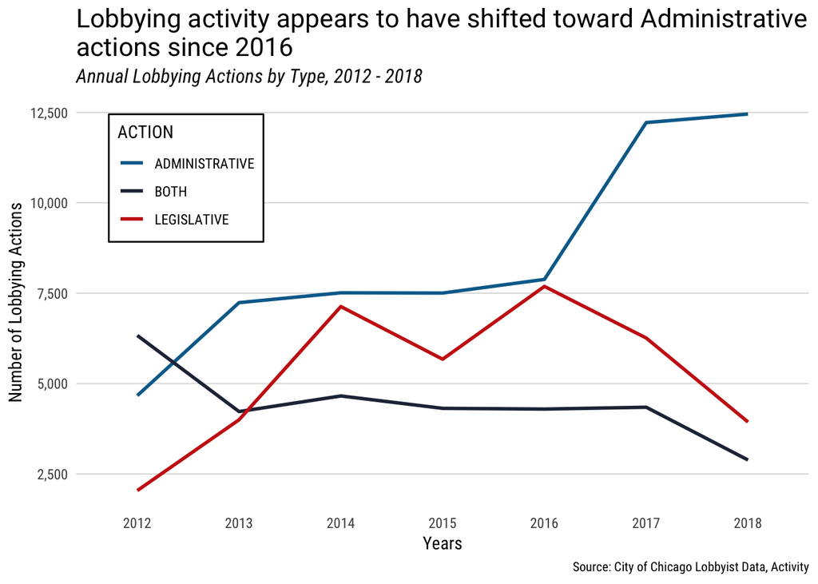

```r
# aggregate by year to show trend
# what happened  in 2017? why seasonality?
# fourier transformation - time to frequency domain
# axes labels, label quarter only, year underneath
# move legend onto plot

# Summarise data into necessary format
#act_summ <-

activity %>%
  mutate(year = format(PERIOD_START, '%Y'),
         PERIOD_START = as.yearqtr(PERIOD_START, format = "%Y-%m-%d")) %>%
  group_by(year, ACTION) %>%
  summarise(n = n()) %>%
  ggplot(aes(year, n)) +
    geom_line(aes(group=ACTION, color=ACTION), size = 1) +
    scale_color_manual(values = as.vector(dark_colors[c('blue', 'purple', 'red')])) +
    scale_y_continuous(label=comma) +
    labs(title="Lobbying activity appears to have shifted toward Administrative \nactions since 2016",
        subtitle="Annual Lobbying Actions by Type, 2012 - 2018",
        caption="Source: City of Chicago Lobbyist Data, Activity",
        x = "Years",
        y = "Number of Lobbying Actions") +
    theme_claire +
        theme(legend.position = c(0.15, 0.8))
```

Lobbying is a commonplace activity at all levels of government. In Chicago, lobbying “Actions” are divided into three categories: Administrative, Legislative, and Both. Administrative actions are meant to spur administrative action, including meetings regarding contract implementation, marketing services to City agencies, or submitting information regarding redevelopment plans. Legislative actions are intended to encourage support or opposition for specific ordinances or bills before the City legislature. The “Both” category includes some combination of the two. There is a notable increase in the number of Administrative actions beginning in 2016 and continuing to the present. this trend warrants further exploration.

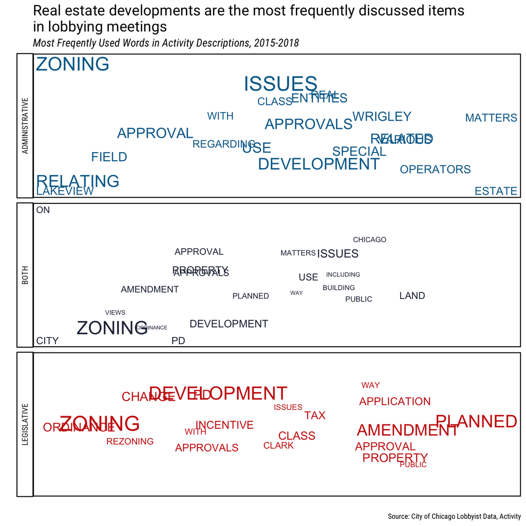

```r
b <- activity %>%
  filter(PERIOD_START > as.Date('2014-12-31')) %>%
  mutate(ACTION_SOUGHT_WORDS = as.vector(str_split(ACTION_SOUGHT, pattern = c(" ", ", ")))) %>%
  group_by(ACTION) %>%
  summarise(WORDS = paste(ACTION_SOUGHT, collapse = ", ")) %>%
  mutate(WORDS_SEP = as.vector(str_split(WORDS, pattern = "[^a-zA-Z0-9]? ")))

common_words <- c("A", "AND", "AT", "OF", "IN", "THE", "BE", "TO", "THAT", "HAVE",
                  "IT", "/", "&", "FOR", "N", "E", "W", "S", "L")

# Probably a better way to do this
admin <- data.frame(table(b$WORDS_SEP[1])) %>%
  mutate(ACTION = 'ADMINISTRATIVE') %>%
  rename(WORD = Var1, COUNT = Freq) %>%
  arrange(desc(COUNT)) %>%
  slice(1:30)
both <- data.frame(table(b$WORDS_SEP[2])) %>%
  mutate(ACTION = 'BOTH') %>%
  rename(WORD = Var1, COUNT = Freq) %>%
  arrange(desc(COUNT)) %>%
  slice(1:30)
legis <- data.frame(table(b$WORDS_SEP[3])) %>%
  mutate(ACTION = 'LEGISLATIVE') %>%
  rename(WORD = Var1, COUNT = Freq) %>%
  arrange(desc(COUNT)) %>%
  slice(1:30)

word_counts <- admin %>%
  rbind(both) %>%
  rbind(legis) %>%
  filter(!(WORD %in% common_words))

word_counts %>%
ggplot +
  aes(x = 1, y = 1, size = COUNT, label = WORD, color = ACTION) +
  geom_text_repel(segment.size = 0, force = 200) +
  scale_size(range = c(2, 8), guide = FALSE) +
  scale_color_manual(values = as.vector(dark_colors[c('blue', 'purple', 'red')])) +
  scale_y_continuous(breaks = NULL) +
  scale_x_continuous(breaks = NULL) +
  labs(x = '', y = '') +
  facet_grid(rows = vars(ACTION), switch="both") +
  labs(title="Real estate developments are the most frequently discussed items \nin lobbying meetings",
         subtitle="Most Freqently Used Words in Activity Descriptions, 2015-2018",
         caption="Source: City of Chicago Lobbyist Data, Activity") +
  theme_claire +
  theme(panel.background = element_blank(),
        panel.border = element_rect(color="black",size=1, fill=NA),
        strip.background = element_rect(color="black",size=0.5),
        legend.position = "none")
```

Regardless of the type of activity (Administrative, Legislative, or Both), the most commonly used in the activity description are words like “zoning”, “development”, and “approval”. This suggests the the majority of the lobbying meetings of all types center on issues surrounding real estate development.

# Private Industry and Lobbying

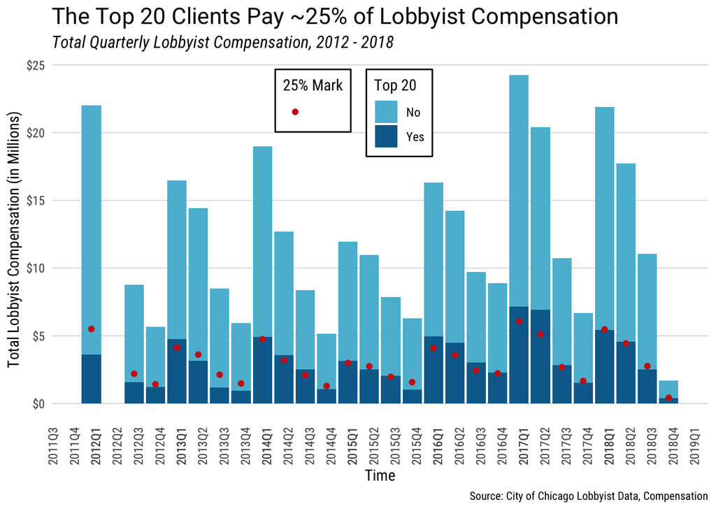

```r
# Top 25 flag
top_20 <- compensation %>%
  group_by(CLIENT_NAME) %>%
  summarise(sum = sum(COMPENSATION_AMOUNT), cnt = n()) %>%
  arrange(desc(sum)) %>%
  slice(1:20) %>%
  select(CLIENT_NAME)

compensation %<>% mutate(TOP20 = ifelse(CLIENT_NAME %in% top_20$CLIENT_NAME, "Yes", "No"))

c <- compensation %>%
  mutate(PERIOD_START = as.yearqtr(PERIOD_START, format = "%Y-%m-%d")) %>%
  #filter(PERIOD_START < as.Date('2018-07-01')) %>%
  group_by(TOP20, PERIOD_START) %>%
  summarise(sum = sum(COMPENSATION_AMOUNT), n = n()) %>%
  mutate(sum = sum/1000000) %>%
  ggplot(aes(PERIOD_START, sum)) +
    geom_col(aes(fill=factor(TOP20, levels=c("No","Yes")))) +
    scale_y_continuous(label=dollar_format()) +
    scale_x_yearqtr(limits = c('2012 Q1', '2018 Q4'), format = "%YQ%q", n = 28) +
    scale_fill_manual(values=c(as.vector(light_colors['blue']), as.vector(dark_colors['blue']))) +
    labs(title="The Top 20 Clients Pay ~25% of Lobbyist Compensation",
         subtitle="Total Quarterly Lobbyist Compensation, 2012 - 2018",
         caption="Source: City of Chicago Lobbyist Data, Compensation",
         x = "Time",
         y = "Total Lobbyist Compensation (in Millions)") +
  theme_claire +
  theme(axis.text.x = element_text(angle = 90, hjust = 1),
        legend.box = 'horizontal',
        legend.position = c(0.46, 0.85)) +
  guides(fill=guide_legend(title="Top 20"))

c + geom_point(data = compensation %>%
  mutate(PERIOD_START = as.yearqtr(PERIOD_START, format = "%Y-%m-%d")) %>%
  #filter(PERIOD_START < as.Date('2018-07-01')) %>%
  group_by(PERIOD_START) %>%
  summarise(pct_25 = sum(COMPENSATION_AMOUNT) * .25/1000000, n = n()), aes(PERIOD_START, pct_25, color = dark_colors['red'])) +
  scale_color_identity(name = "25% Mark",
                      labels = c(""),
                      guide = "legend")
```

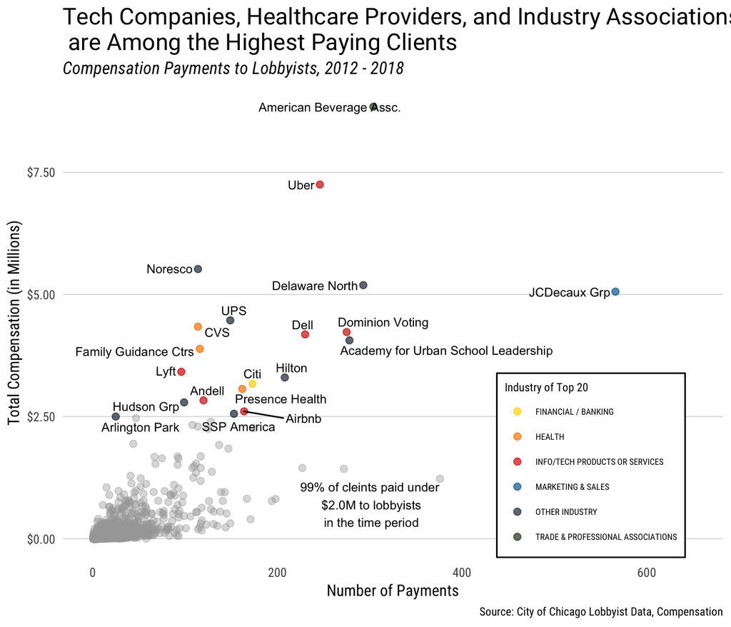

```r
# Map actual name to target name
keys <- c("ACADEMY FOR URBAN SCHOOL LEADERSHIP", "AIRBNB", "AMERICAN BEVERAGE ASSOCIATION", "ANDELL INC", "ARLINGTON PARK", "CITIBANK, NA",
          "CVS CAREMARK CORP", "DELAWARE NORTH COMPANIES", "DELL", "DOMINION VOTING SYSTEMS INC", "FAMILY GUIDANCE CENTERS INC",
          "HILTON WORLDWIDE", "HUDSON GROUP", "JCDECAUX GROUP", "LYFT", "NORESCO LLC", "PRESENCE HEALTH", "SSP AMERICA INC",
          "UBER","UNITED PARCEL SERVICE")
values <- c("Academy for Urban School Leadership", "Airbnb", "American Beverage Assc.", "Andell", "Arlington Park", "Citi",
            "CVS", "Delaware North", "Dell", "Dominion Voting", "Family Guidance Ctrs",
            "Hilton", "Hudson Grp", "JCDecaux Grp", "Lyft", "Noresco", "Presence Health", "SSP America",
            "Uber", "UPS")
nick_name <- setNames(as.list(values), keys)

top <- compensation %>%
  filter(TOP20 == 'Yes') %>%
  group_by(CLIENT_NAME, CLIENT_INDUSTRY) %>%
  summarise(sum=sum(COMPENSATION_AMOUNT), n = n()) %>%
  mutate(sum = sum/1000000,
         INDUSTRY = if_else(CLIENT_INDUSTRY %in% c('HOSPITALITY / RESTAURANT', 'PUBLIC UTILITIES',
                                                   'RETAIL', 'EDUCATION', 'RACING & WAGERING', 'TRANSPORTATION'),
                            'OTHER INDUSTRY', CLIENT_INDUSTRY),
         NICK_NAME = nick_name[CLIENT_NAME])

t <-compensation %>%
  filter(TOP20 == 'No') %>%
  group_by(CLIENT_NAME) %>%
  summarise(sum=sum(COMPENSATION_AMOUNT), n = n()) %>%
  mutate(sum = sum/1000000) %>%
  ggplot() +
    geom_point(aes(n, sum), color = light_colors["gray"], size = 2, alpha = 0.4) +
    annotate("text", x = 300, y = .7, label = "99% of cleints paid under\n $2.0M to lobbyists\n in the time period", size = 3)

t + geom_point(data = top, aes(n, sum, color = INDUSTRY), size = 2, alpha = 0.7) +
    geom_text_repel(data = top, aes(n, sum, label = NICK_NAME), check_overlap = TRUE, size = 3, hjust = 0, nudge_x = 0.1) +
    scale_y_continuous(label=dollar_format()) +
    scale_color_manual(values = as.vector(dark_colors[1:6])) +
    xlim(0, 650) +
    labs(title="Tech Companies, Healthcare Providers, and Industry Associations\n are Among the Highest Paying Clients",
         subtitle="Compensation Payments to Lobbyists, 2012 - 2018",
         caption="Source: City of Chicago Lobbyist Data, Compensation",
         x = "Number of Payments",
         y = "Total Compensation (in Millions)") +
    theme_claire +
    theme(legend.text=element_text(size=6),
          legend.title=element_text(size=8),
          legend.position = c(0.8, 0.2)) +
  guides(color=guide_legend(title="Industry of Top 20"))
```

In contrast to the vast majority of clients, the top 20 clients in terms of compensation to lobbyists each paid over $2.5M between 2012 and 2018. While any organization, including non-profits and other public service entities, may lobby government, the top 20 clients are almost all private companies with a national profile. The top spender, the American Beverage Association, has consistently paid lobbyists to advocate to the Mayor and City Council against legislation like the proposed Soda Tax and a ban on high-caffeine energy drinks proposed in 2013. Technology companies including Uber, Lyft, and Dell also rank high on the list.

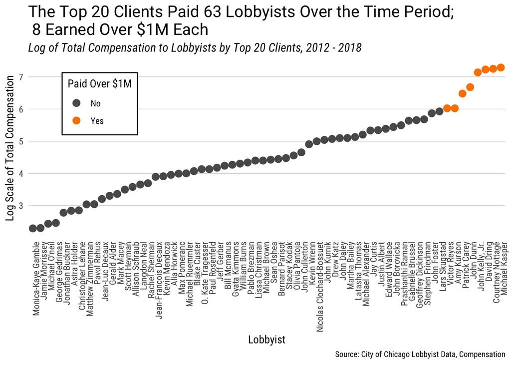

```r
# try log scale? add annotation,
compensation %>%
  filter(TOP20 == 'Yes') %>%
  group_by(LOBBYIST_NAME) %>%
  summarise(sum = sum(COMPENSATION_AMOUNT), log_sum = log10(sum(COMPENSATION_AMOUNT)), n = n()) %>%
  mutate(sum = sum/1000000,
         cat = if_else(sum < 1, 'No', 'Yes')) %>%
  ggplot(aes(reorder(tools::toTitleCase(tolower(LOBBYIST_NAME)), log_sum), log_sum)) +
    geom_point(aes(color = cat), stat = 'identity', size = 3) +
    scale_color_manual(values = as.vector(dark_colors[c("gray", "orange")])) +
    labs(title="The Top 20 Clients Paid 63 Lobbyists Over the Time Period;\n 8 Earned Over $1M Each",
         subtitle="Log of Total Compensation to Lobbyists by Top 20 Clients, 2012 - 2018",
         caption="Source: City of Chicago Lobbyist Data, Compensation",
         x = "Lobbyist",
         y = "Log Scale of Total Compensation") +
    theme_claire +
    theme(axis.text.x = element_text(angle = 90, hjust = 1),
          legend.position = c(0.15, 0.75)) +
    guides(color=guide_legend(title="Paid Over $1M"))
```

Between 2012 and 2018, the top 20 clients paid 63 lobbyists to represent their interest, with 8 earning over $1M. David Dring, Courtney Nottage, and Michael Kasper, all employed by the lawfirm Fletcher, O’Brien, Kasper, and Nottage, earned over $15M each. John Kelly, Jr., the president of AllCirco earned $13.7M. Victor Reyes and Amy Kurson are partners at the lawfirm Reyes Kurson and each earned about $1M. Patrick Carey and John Dunn are both partners at the lawfirm McGuire Woods and earned $3.0M and $4.8M, respectively.

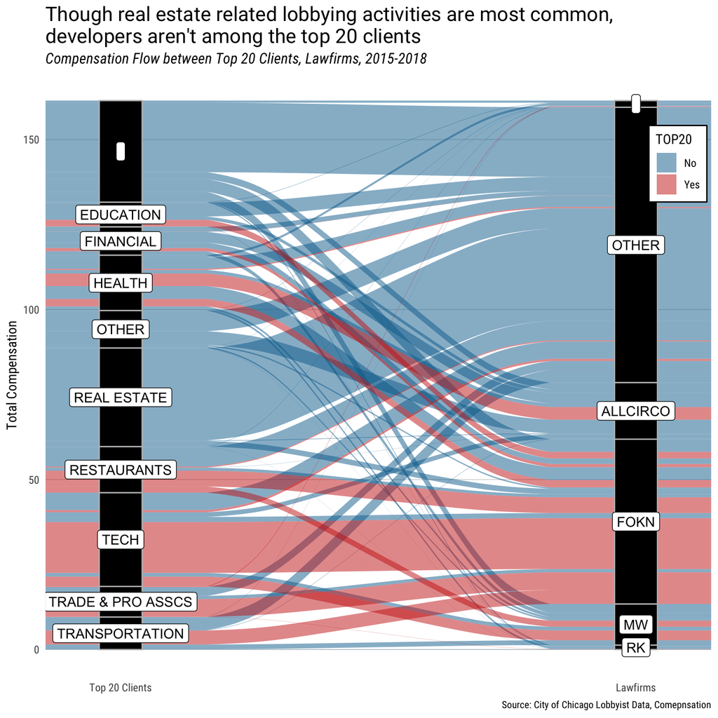

```r
# industry > lawfirms > city council, others
keep <- compensation %>%
  filter(PERIOD_START > as.Date('2014-12-31')) %>%
  group_by(CLIENT_INDUSTRY) %>%
  summarise(sum = sum(COMPENSATION_AMOUNT)) %>%
  arrange(desc(sum)) %>%
  mutate(KEEP = if_else(sum > 7000000, 1, 0))

lobbyist_name <- c("VICTOR REYES", "AMY KURSON", "PATRICK CAREY", "JOHN DUNN", "JOHN KELLY, JR.",
                   "DAVID DRING", "COURTNEY NOTTAGE", "MICHAEL KASPER")
lawfirm <- c("", "RK", "MW", "MW", "ALLCIRCO",
             "FOKN", "FOKN", "FOKN")
law_names <- setNames(as.list(lawfirm), lobbyist_name)

full_industry <- c("REAL ESTATE & CONSTRUCTION", "INFO/TECH PRODUCTS OR SERVICES", "HOSPITALITY / RESTAURANT",
                   "TRADE & PROFESSIONAL ASSOCIATIONS", "FINANCIAL / BANKING")
short_industry <- c("REAL ESTATE", "TECH", "RESTAURANTS",
                    "TRADE & PRO ASSCS", "FINANCIAL")
industry_lookup <- setNames(as.list(short_industry), full_industry)

compensation %>%
  left_join(keep, by = "CLIENT_INDUSTRY") %>%
  mutate(LAWFIRM = if_else(LOBBYIST_NAME %in% names(law_names), as.character(law_names[LOBBYIST_NAME]), "OTHER"),
         REAL_ESTATE = if_else(str_detect(CLIENT_INDUSTRY, "REAL ESTATE"), "Yes", "No"),
         REAL_ESTATE = if_else(is.na(REAL_ESTATE), "No", REAL_ESTATE),
         CLIENT_INDUSTRY = if_else(KEEP == 0, "OTHER", CLIENT_INDUSTRY),
         CLIENT_INDUSTRY = if_else(CLIENT_INDUSTRY %in% names(industry_lookup), as.character(industry_lookup[CLIENT_INDUSTRY]), CLIENT_INDUSTRY)) %>%
  filter(PERIOD_START > as.Date('2014-12-31') & KEEP == 1) %>%
  group_by(CLIENT_INDUSTRY, TOP20, LAWFIRM) %>%
  summarise(sum = sum(COMPENSATION_AMOUNT)) %>%
  mutate(sum = sum/1000000) %>%
  ggplot(aes(y = sum, axis1 = CLIENT_INDUSTRY, axis2 = LAWFIRM)) +
    geom_alluvium(aes(fill = TOP20)) +
    geom_stratum(width = 1/12, fill = "black", color = "grey") +
    geom_label(stat = "stratum", label.strata = TRUE) +
    scale_x_discrete(limits = c("Top 20 Clients", "Lawfirms"), expand = c(.05, .05)) +
    scale_fill_manual(values = as.vector(dark_colors[4:3])) +
    labs(title="Though real estate related lobbying activities are most common, \ndevelopers aren't among the top 20 clients",
         subtitle="Compensation Flow between Top 20 Clients, Lawfirms, 2015-2018",
         caption="Source: City of Chicago Lobbyist Data, Comepnsation",
         y = "Total Compensation") +
    theme_claire +
  theme(legend.position = c(.95, .85))
```

# Direct Influence on City Council

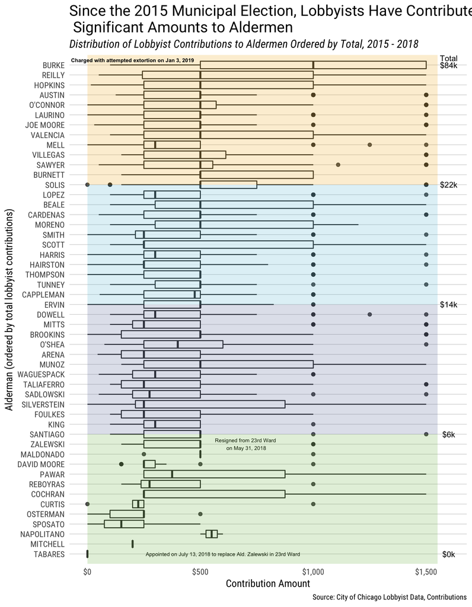

```r
council_last <- str_trim(toupper(str_extract(council$` Person Name`, '^[A-Za-z\']+')))

alderman_contributions <- contribution %>%
  mutate(ALDERMAN = "") %>%
  mutate(ALDERMAN = if_else(str_detect(RECIPIENT, 'ARENA'), 'ARENA', ALDERMAN),
         ALDERMAN = if_else(str_detect(RECIPIENT, 'AUSTIN'), 'AUSTIN', ALDERMAN),
         ALDERMAN = if_else(str_detect(RECIPIENT, 'BEALE'), 'BEALE', ALDERMAN),
         ALDERMAN = if_else(str_detect(RECIPIENT, 'BROOKINS'), 'BROOKINS', ALDERMAN),
         ALDERMAN = if_else(str_detect(RECIPIENT, 'BURKE'), 'BURKE', ALDERMAN),
         ALDERMAN = if_else(str_detect(RECIPIENT, 'BURNETT'), 'BURNETT', ALDERMAN),
         ALDERMAN = if_else(str_detect(RECIPIENT, 'CAPPLEMAN'), 'CAPPLEMAN', ALDERMAN),
         ALDERMAN = if_else(str_detect(RECIPIENT, 'CARDENAS'), 'CARDENAS', ALDERMAN),
         ALDERMAN = if_else(str_detect(RECIPIENT, 'COCHRAN'), 'COCHRAN', ALDERMAN),
         ALDERMAN = if_else(str_detect(RECIPIENT, 'CURTIS'), 'CURTIS', ALDERMAN),
         ALDERMAN = if_else(str_detect(RECIPIENT, 'DOWELL'), 'DOWELL', ALDERMAN),
         ALDERMAN = if_else(str_detect(RECIPIENT, 'EMANUEL'), 'EMANUEL', ALDERMAN),
         ALDERMAN = if_else(str_detect(RECIPIENT, 'ERVIN'), 'ERVIN', ALDERMAN),
         ALDERMAN = if_else(str_detect(RECIPIENT, 'FOULKES'), 'FOULKES', ALDERMAN),
         ALDERMAN = if_else(str_detect(RECIPIENT, 'HAIRSTON'), 'HAIRSTON', ALDERMAN),
         ALDERMAN = if_else(str_detect(RECIPIENT, 'HARRIS'), 'HARRIS', ALDERMAN),
         ALDERMAN = if_else(str_detect(RECIPIENT, 'HOPKINS'), 'HOPKINS', ALDERMAN),
         ALDERMAN = if_else(str_detect(RECIPIENT, 'KING'), 'KING', ALDERMAN),
         ALDERMAN = if_else(str_detect(RECIPIENT, 'LAURINO'), 'LAURINO', ALDERMAN),
         ALDERMAN = if_else(str_detect(RECIPIENT, 'LOPEZ'), 'LOPEZ', ALDERMAN),
         ALDERMAN = if_else(str_detect(RECIPIENT, 'MALDONADO'), 'MALDONADO', ALDERMAN),
         ALDERMAN = if_else(str_detect(RECIPIENT, 'MELL'), 'MELL', ALDERMAN),
         ALDERMAN = if_else(str_detect(RECIPIENT, 'MITCHELL'), 'MITCHELL', ALDERMAN),
         ALDERMAN = if_else(str_detect(RECIPIENT, 'MITTS'), 'MITTS', ALDERMAN),
         ALDERMAN = if_else(str_detect(RECIPIENT, 'JOE MOORE'), 'JOE MOORE', ALDERMAN),
         ALDERMAN = if_else(str_detect(RECIPIENT, 'DAVID MOORE'), 'DAVID MOORE', ALDERMAN),
         ALDERMAN = if_else(str_detect(RECIPIENT, 'MORENO'), 'MORENO', ALDERMAN),
         ALDERMAN = if_else(str_detect(RECIPIENT, 'MUNOZ'), 'MUNOZ', ALDERMAN),
         ALDERMAN = if_else(str_detect(RECIPIENT, 'NAPOLITANO'), 'NAPOLITANO', ALDERMAN),
         ALDERMAN = if_else(str_detect(RECIPIENT, "O'CONNOR"), "O'CONNOR", ALDERMAN),
         ALDERMAN = if_else(str_detect(RECIPIENT, "O'SHEA"), "O'SHEA", ALDERMAN),
         ALDERMAN = if_else(str_detect(RECIPIENT, 'OSTERMAN'), 'OSTERMAN', ALDERMAN),
         ALDERMAN = if_else(str_detect(RECIPIENT, 'PAWAR'), 'PAWAR', ALDERMAN),
         ALDERMAN = if_else(str_detect(RECIPIENT, 'QUINN'), 'QUINN', ALDERMAN),
         ALDERMAN = if_else(str_detect(RECIPIENT, 'RAMIREZ'), 'RAMIREZ', ALDERMAN),
         ALDERMAN = if_else(str_detect(RECIPIENT, 'REBOYRAS'), 'REBOYRAS', ALDERMAN),
         ALDERMAN = if_else(str_detect(RECIPIENT, 'REILLY'), 'REILLY', ALDERMAN),
         ALDERMAN = if_else(str_detect(RECIPIENT, 'SADLOWSKI'), 'SADLOWSKI', ALDERMAN),
         ALDERMAN = if_else(str_detect(RECIPIENT, 'SANTIAGO'), 'SANTIAGO', ALDERMAN),
         ALDERMAN = if_else(str_detect(RECIPIENT, 'SAWYER'), 'SAWYER', ALDERMAN),
         ALDERMAN = if_else(str_detect(RECIPIENT, 'SCOTT'), 'SCOTT', ALDERMAN),
         ALDERMAN = if_else(str_detect(RECIPIENT, 'SILVERSTEIN'), 'SILVERSTEIN', ALDERMAN),
         ALDERMAN = if_else(str_detect(RECIPIENT, 'SMITH'), 'SMITH', ALDERMAN),
         ALDERMAN = if_else(str_detect(RECIPIENT, 'SOLIS'), 'SOLIS', ALDERMAN),
         ALDERMAN = if_else(str_detect(RECIPIENT, 'SPOSATO'), 'SPOSATO', ALDERMAN),
         ALDERMAN = if_else(str_detect(RECIPIENT, 'TABARES'), 'TABARES', ALDERMAN),
         ALDERMAN = if_else(str_detect(RECIPIENT, 'TALIAFERRO'), 'TALIAFERRO', ALDERMAN),
         ALDERMAN = if_else(str_detect(RECIPIENT, 'THOMPSON'), 'THOMPSON', ALDERMAN),
         ALDERMAN = if_else(str_detect(RECIPIENT, 'TUNNEY'), 'TUNNEY', ALDERMAN),
         ALDERMAN = if_else(str_detect(RECIPIENT, 'VALENCIA'), 'VALENCIA', ALDERMAN),
         ALDERMAN = if_else(str_detect(RECIPIENT, 'VILLEGAS'), 'VILLEGAS', ALDERMAN),
         ALDERMAN = if_else(str_detect(RECIPIENT, 'WAGUESPACK'), 'WAGUESPACK', ALDERMAN),
         ALDERMAN = if_else(str_detect(RECIPIENT, 'ZALEWSKI'), 'ZALEWSKI', ALDERMAN)
         ) %>%
  filter(ALDERMAN != "" & ALDERMAN != "EMANUEL")

ald_totals <- alderman_contributions %>%
  filter(CONTRIBUTION_DATE > as.Date('2014-12-31')) %>%
  group_by(ALDERMAN) %>%
  summarise(sum = sum(AMOUNT), n = n()) %>%
  arrange(desc(sum))

# Set names for annotations
high_name <- 'BURKE'
high_mid_name <- 'SOLIS'
mid_name <- 'ERVIN'
low_mid_name <- 'SANTIAGO'
low_name <- 'TABARES'

# Set amounts for annotations
high_amt <- '$84k'
high_mid_amt <- '$22k'
mid_amt <- '$14k'
low_mid_amt <- '$6k'
low_amt <- '$0k'

alderman_contributions %>%
  filter(CONTRIBUTION_DATE > as.Date('2014-12-31')) %>%
  left_join(ald_totals, by = 'ALDERMAN') %>% #glimpse()
  #mutate(ALDERMAN = tools::toTitleCase(tolower(ALDERMAN))) %>% glimpse()
  ggplot() +
  geom_boxplot(aes(reorder(ALDERMAN, sum), AMOUNT), alpha = 0.8) +
  coord_flip() +
  annotate("text", x = 50.7, y = 1600, label = "Total", size = 3) +
  annotate("text", x = high_name, y = 1600, label = high_amt, size = 3) +
  annotate("text", x = high_mid_name, y = 1600, label = high_mid_amt, size = 3) +
  annotate("text", x = mid_name, y = 1600, label = mid_amt, size = 3) +
  annotate("text", x = low_mid_name, y = 1600, label = low_mid_amt, size = 3) +
  annotate("text", x = low_name, y = 1600, label = low_amt, size = 3) +
  annotate("text", x = 'TABARES', y = 600, label = "Appointed on July 13, 2018 to replace Ald. Zalewski in 23rd Ward", size = 2) +
  annotate("text", x = 'ZALEWSKI', y = 700, label = "Resigned from 23rd Ward\n on May 31, 2018", size = 2) +
  annotate("rect", xmin = high_mid_name, xmax = 51, ymin = 0, ymax = 1550, fill = light_colors["orange"], alpha = .2) +
  annotate("rect", xmin = mid_name, xmax = high_mid_name, ymin = 0, ymax = 1550, fill = light_colors["blue"], alpha = .2) +
  annotate("rect", xmin = low_mid_name, xmax = mid_name, ymin = 0, ymax = 1550, fill = light_colors["purple"], alpha = .2) +
  annotate("rect", xmin = 0, xmax = low_mid_name, ymin = 0, ymax = 1550, fill = light_colors["green"], alpha = .2) +
  annotate("text", x = 50.5, y = 200, label = "Charged with attempted extortion on Jan 3, 2019", size = 2, fontface = 2) +
  scale_y_continuous(label=dollar_format()) +
  labs(title="Since the 2015 Municipal Election, Lobbyists Have Contributed\n Significant Amounts to Aldermen",
         subtitle="Distribution of Lobbyist Contributions to Aldermen Ordered by Total, 2015 - 2018",
         caption="Source: City of Chicago Lobbyist Data, Contributions",
         x = "Alderman (ordered by total lobbyist contributions)",
         y = "Contribution Amount") +
  theme_claire
```

```r
#ald_totals
```

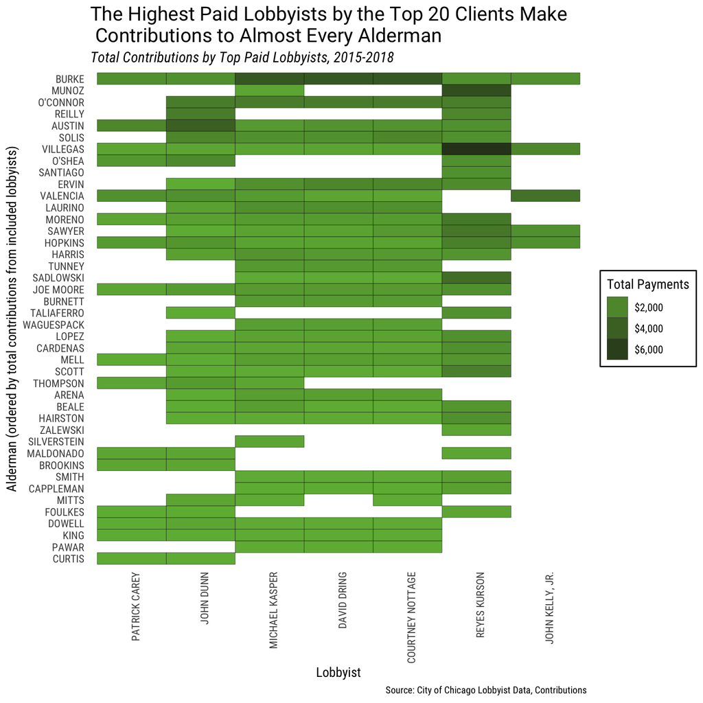

```r
# shows more about who is and who isn't
# Bin lobbyists by location? octant of community areas
# sankey diagram

paid_by_top20 <- compensation %>%
  filter(TOP20 == 'Yes') %>%
  group_by(LOBBYIST_NAME) %>%
  summarise(sum = sum(COMPENSATION_AMOUNT), n = n()) %>%
  filter(sum >= 1000000)

alderman_contributions %>%
  mutate(paid_top20 = if_else(LOBBYIST_NAME %in% paid_by_top20$LOBBYIST_NAME | LOBBYIST_NAME == 'REYES KURSON', TRUE, FALSE))%>%
  filter(CONTRIBUTION_DATE > as.Date('2014-12-31') & paid_top20) %>%
  left_join(ald_totals, by = 'ALDERMAN') %>%
  group_by(ALDERMAN, LOBBYIST_NAME) %>%
  summarise(sum = sum(AMOUNT), n = n()) %>%
  ggplot() +
    geom_tile(aes(reorder(LOBBYIST_NAME, sum), reorder(ALDERMAN, sum), fill = sum), color = 'black') +
    scale_fill_gradient(low = light_colors['green'], high = dark_colors['green'], label=dollar_format()) +
    labs(title="The Highest Paid Lobbyists by the Top 20 Clients Make\n Contributions to Almost Every Alderman",
         subtitle="Total Contributions by Top Paid Lobbyists, 2015-2018",
         caption="Source: City of Chicago Lobbyist Data, Contributions",
         x = "Lobbyist",
         y = "Alderman (ordered by total contributions from included lobbyists)") +
    theme_claire +
    theme(axis.text.x = element_text(angle = 90, hjust = 1),
          panel.grid = element_blank()) +
  guides(fill=guide_legend(title="Total Payments"))
```

The lobbyists paid the most compensation by the top 20 firms appear to have a strategy of blanket, moderate, financial support for almost all aldermen. One notable exception is John Kelly, President and Owner of the public affairs consulting firm [All-Circo, Inc](http://www.allcirco.com/), who appears to concentrate on only a few. Two of the eight attorneys paid over $1M, Amy Kurson and Victor Reyes, are both partners at the lawfirm Reyes Kurson. Their contribution data was not included in the data protal contribution records, so aggregate records from the firm were added from IllinoisSunshine.com.